# Ford GoBike System Data Analysis

## Introduction

This data set includes information about individual rides made in the Ford GoBike system covering the greater San Francisco Bay area between 2019-02-01 and 2019-02-28.

## Preliminary Wrangling

```python
# import all packages and set plots to be embedded inline
import numpy as np
import pandas as pd
import matplotlib.pyplot as plt
import seaborn as sns

sns.set_theme(style='whitegrid')
%matplotlib inline
```

```python
bikes = pd.read_csv('201902-fordgobike-tripdata.csv')
```

```python
bikes.head()
```

|  | duration_sec | start_time | end_time | start_station_id | start_station_name | start_station_latitude | start_station_longitude | end_station_id | end_station_name | end_station_latitude | end_station_longitude | bike_id | user_type | member_birth_year | member_gender | bike_share_for_all_trip |
| --- | --- | --- | --- | --- | --- | --- | --- | --- | --- | --- | --- | --- | --- | --- | --- | --- |
| 0 | 52185 | 2019-02-28 17:32:10.1450 | 2019-03-01 08:01:55.9750 | 21.0 | Montgomery St BART Station (Market St at 2nd St) | 37.789625 | -122.400811 | 13.0 | Commercial St at Montgomery St | 37.794231 | -122.402923 | 4902 | Customer | 1984.0 | Male | No |
| 1 | 42521 | 2019-02-28 18:53:21.7890 | 2019-03-01 06:42:03.0560 | 23.0 | The Embarcadero at Steuart St | 37.791464 | -122.391034 | 81.0 | Berry St at 4th St | 37.775880 | -122.393170 | 2535 | Customer | NaN | NaN | No |
| 2 | 61854 | 2019-02-28 12:13:13.2180 | 2019-03-01 05:24:08.1460 | 86.0 | Market St at Dolores St | 37.769305 | -122.426826 | 3.0 | Powell St BART Station (Market St at 4th St) | 37.786375 | -122.404904 | 5905 | Customer | 1972.0 | Male | No |
| 3 | 36490 | 2019-02-28 17:54:26.0100 | 2019-03-01 04:02:36.8420 | 375.0 | Grove St at Masonic Ave | 37.774836 | -122.446546 | 70.0 | Central Ave at Fell St | 37.773311 | -122.444293 | 6638 | Subscriber | 1989.0 | Other | No |
| 4 | 1585 | 2019-02-28 23:54:18.5490 | 2019-03-01 00:20:44.0740 | 7.0 | Frank H Ogawa Plaza | 37.804562 | -122.271738 | 222.0 | 10th Ave at E 15th St | 37.792714 | -122.248780 | 4898 | Subscriber | 1974.0 | Male | Yes |

### Assessing

```python
bikes.start_time.max()
```

```
'2019-02-28 23:59:18.5480'
```

```python
bikes.info()
```

```
<class 'pandas.core.frame.DataFrame'>
RangeIndex: 183412 entries, 0 to 183411
Data columns (total 16 columns):
 #   Column                   Non-Null Count   Dtype
---  ------                   --------------   -----
 0   duration_sec             183412 non-null  int64
 1   start_time               183412 non-null  object
 2   end_time                 183412 non-null  object
 3   start_station_id         183215 non-null  float64
 4   start_station_name       183215 non-null  object
 5   start_station_latitude   183412 non-null  float64
 6   start_station_longitude  183412 non-null  float64
 7   end_station_id           183215 non-null  float64
 8   end_station_name         183215 non-null  object
 9   end_station_latitude     183412 non-null  float64
 10  end_station_longitude    183412 non-null  float64
 11  bike_id                  183412 non-null  int64
 12  user_type                183412 non-null  object
 13  member_birth_year        175147 non-null  float64
 14  member_gender            175147 non-null  object
 15  bike_share_for_all_trip  183412 non-null  object
dtypes: float64(7), int64(2), object(7)
memory usage: 22.4+ MB
```

```python
bikes.isnull().sum()
```

```
duration_sec                  0
start_time                    0
end_time                      0
start_station_id            197
start_station_name          197
start_station_latitude        0
start_station_longitude       0
end_station_id              197
end_station_name            197
end_station_latitude          0
end_station_longitude         0
bike_id                       0
user_type                     0
member_birth_year          8265
member_gender              8265
bike_share_for_all_trip       0
dtype: int64
```

```python
bikes.duplicated().sum()
```

```
0
```

```python
bikes.nunique()
```

```
duration_sec                 4752
start_time                 183401
end_time                   183397
start_station_id              329
start_station_name            329
start_station_latitude        334
start_station_longitude       335
end_station_id                329
end_station_name              329
end_station_latitude          335
end_station_longitude         335
bike_id                      4646
user_type                       2
member_birth_year              75
member_gender                   3
bike_share_for_all_trip         2
dtype: int64
```

```python
bikes['member_gender'].unique()
```

```
array(['Male', nan, 'Other', 'Female'], dtype=object)
```

```python
bikes.sample(5)
```

|  | duration_sec | start_time | end_time | start_station_id | start_station_name | start_station_latitude | start_station_longitude | end_station_id | end_station_name | end_station_latitude | end_station_longitude | bike_id | user_type | member_birth_year | member_gender | bike_share_for_all_trip |
| --- | --- | --- | --- | --- | --- | --- | --- | --- | --- | --- | --- | --- | --- | --- | --- | --- |
| 72814 | 291 | 2019-02-19 15:40:30.5810 | 2019-02-19 15:45:22.0010 | 240.0 | Haste St at Telegraph Ave | 37.866043 | -122.258804 | 253.0 | Haste St at College Ave | 37.866418 | -122.253799 | 5129 | Subscriber | 1995.0 | Male | Yes |
| 1776 | 565 | 2019-02-28 18:41:12.6750 | 2019-02-28 18:50:37.7770 | 49.0 | S Park St at 3rd St | 37.780760 | -122.394989 | 3.0 | Powell St BART Station (Market St at 4th St) | 37.786375 | -122.404904 | 6337 | Subscriber | 1992.0 | Male | No |
| 109689 | 955 | 2019-02-12 18:35:28.4690 | 2019-02-12 18:51:23.7170 | 109.0 | 17th St at Valencia St | 37.763316 | -122.421904 | 377.0 | Fell St at Stanyan St | 37.771917 | -122.453704 | 5030 | Subscriber | 1991.0 | Male | Yes |
| 153082 | 174 | 2019-02-06 13:44:23.7210 | 2019-02-06 13:47:18.4050 | 41.0 | Golden Gate Ave at Polk St | 37.781270 | -122.418740 | 43.0 | San Francisco Public Library (Grove St at Hyde... | 37.778768 | -122.415929 | 4744 | Subscriber | 1991.0 | Male | No |
| 181017 | 190 | 2019-02-01 09:43:13.2290 | 2019-02-01 09:46:24.1490 | 233.0 | 4th Ave at E 12th St (Temporary Location) | 37.795913 | -122.255547 | 201.0 | 10th St at Fallon St | 37.797673 | -122.262997 | 3606 | Subscriber | 1984.0 | Female | No |

```python
bikes['start_time'].min()
```

```
'2019-02-01 00:00:20.6360'
```

#### Quality issues

- member_birth_year, start_time and end_time coulmns have wrong data types
- start-station_id, start_station_name, end_station_id, end_station_name, member_birth_year, member_gender have missing values

#### cleaning

```python
bikes_clean = bikes.copy()
```

```python
# Changing start_time, end_time to datetime
bikes_clean['start_time'] = pd.to_datetime(bikes_clean['start_time'])
bikes_clean['end_time'] = pd.to_datetime(bikes_clean['end_time'])

# confirming the change
bikes_clean[['start_time', 'end_time']].dtypes
```

```
start_time    datetime64[ns]
end_time      datetime64[ns]
dtype: object
```

```python
# drop all rows with missing values
bikes_clean.dropna(inplace=True)
bikes_clean.isna().sum()
```

```
duration_sec               0
start_time                 0
end_time                   0
start_station_id           0
start_station_name         0
start_station_latitude     0
start_station_longitude    0
end_station_id             0
end_station_name           0
end_station_latitude       0
end_station_longitude      0
bike_id                    0
user_type                  0
member_birth_year          0
member_gender              0
bike_share_for_all_trip    0
dtype: int64
```

```python
# conevrting member_birth_year to int64
bikes_clean['member_birth_year'] = bikes_clean['member_birth_year'].astype('int64')

# confirming change
bikes_clean['member_birth_year'].dtype
```

```
dtype('int64')
```

```python
bikes_clean.info()
```

```
<class 'pandas.core.frame.DataFrame'>
Int64Index: 174952 entries, 0 to 183411
Data columns (total 16 columns):
 #   Column                   Non-Null Count   Dtype
---  ------                   --------------   -----
 0   duration_sec             174952 non-null  int64
 1   start_time               174952 non-null  datetime64[ns]
 2   end_time                 174952 non-null  datetime64[ns]
 3   start_station_id         174952 non-null  float64
 4   start_station_name       174952 non-null  object
 5   start_station_latitude   174952 non-null  float64
 6   start_station_longitude  174952 non-null  float64
 7   end_station_id           174952 non-null  float64
 8   end_station_name         174952 non-null  object
 9   end_station_latitude     174952 non-null  float64
 10  end_station_longitude    174952 non-null  float64
 11  bike_id                  174952 non-null  int64
 12  user_type                174952 non-null  object
 13  member_birth_year        174952 non-null  int64
 14  member_gender            174952 non-null  object
 15  bike_share_for_all_trip  174952 non-null  object
dtypes: datetime64[ns](2), float64(6), int64(3), object(5)
memory usage: 22.7+ MB
```

#### Feature engineering

```python
# creating a day, month, start_hour columns
bikes_clean['week'] = bikes_clean['start_time'].dt.isocalendar().week
bikes_clean['day'] = bikes_clean['start_time'].dt.day_name().str[:3]
bikes_clean['hour'] = bikes_clean['start_time'].dt.hour
```

```python
bikes_clean['week'].value_counts()
```

```
8    50880
6    43202
7    40482
9    28849
5    11539
Name: week, dtype: Int64
```

```python
# creating a TOD-time_of_day
labels = ['early_morning', 'morning', 'afternoon', 'night']
bins = [0, 6, 12, 19, 23]
bikes_clean['TOD'] = pd.cut(bikes_clean['hour'], bins=bins, labels=labels, include_lowest=True)
```

```python
# creating a duration_minutes column
bikes_clean['duration_minutes'] = np.rint(bikes_clean['duration_sec']/60)
```

```python
# making the day and TOD columns ordered
ordered_cats = {'day':['Mon', 'Tue', 'Wed', 'Thu', 'Fri', 'Sat','Sun'],
                'TOD':['early_morning', 'morning', 'afternoon', 'night']}
for col in ordered_cats:
    cat_ordered = pd.api.types.CategoricalDtype(ordered=True, categories=ordered_cats[col])
    bikes_clean[col] = bikes_clean[col].astype(cat_ordered)
```

```python
# creating an age column
bikes_clean['age'] = 2019 - bikes_clean['member_birth_year']
```

```python
bikes_clean['age'].describe()
```

```
count    174952.000000
mean         34.196865
std          10.118731
min          18.000000
25%          27.000000
50%          32.000000
75%          39.000000
max         141.000000
Name: age, dtype: float64
```

```python
bikes_clean[bikes_clean['age'] == 141]
```

|  | duration_sec | start_time | end_time | start_station_id | start_station_name | start_station_latitude | start_station_longitude | end_station_id | end_station_name | end_station_latitude | ... | user_type | member_birth_year | member_gender | bike_share_for_all_trip | week | day | hour | TOD | duration_minutes | age |
| --- | --- | --- | --- | --- | --- | --- | --- | --- | --- | --- | --- | --- | --- | --- | --- | --- | --- | --- | --- | --- | --- |
| 27370 | 1474 | 2019-02-25 09:28:42.161 | 2019-02-25 09:53:17.068 | 15.0 | San Francisco Ferry Building (Harry Bridges Pl... | 37.795392 | -122.394203 | 386.0 | 24th St at Bartlett St | 37.752105 | ... | Customer | 1878 | Female | No | 9 | Mon | 9 | morning | 25.0 | 141 |

1 rows × 22 columns

```python
# the member birth year was probably meant to be 1978 instead of 1878
bikes_clean['member_birth_year'] = bikes_clean['member_birth_year'].replace(1878, 1978)

# re-calculating the age column to make the change
bikes_clean['age'] = 2019 - bikes_clean['member_birth_year']
```

```python
bikes_clean['age'].describe()
```

```
count    174952.000000
mean         34.196294
std          10.115522
min          18.000000
25%          27.000000
50%          32.000000
75%          39.000000
max         119.000000
Name: age, dtype: float64
```

```python
# creating age_group column
a_bins = [18,35,60,119]
grp = ['young', 'middle_age', 'senior']
bikes_clean['age_group'] = pd.cut(bikes_clean['age'], bins=a_bins, labels=grp, include_lowest=True)
```

```python
bikes_clean.head()
```

|  | duration_sec | start_time | end_time | start_station_id | start_station_name | start_station_latitude | start_station_longitude | end_station_id | end_station_name | end_station_latitude | ... | member_birth_year | member_gender | bike_share_for_all_trip | week | day | hour | TOD | duration_minutes | age | age_group |
| --- | --- | --- | --- | --- | --- | --- | --- | --- | --- | --- | --- | --- | --- | --- | --- | --- | --- | --- | --- | --- | --- |
| 0 | 52185 | 2019-02-28 17:32:10.145 | 2019-03-01 08:01:55.975 | 21.0 | Montgomery St BART Station (Market St at 2nd St) | 37.789625 | -122.400811 | 13.0 | Commercial St at Montgomery St | 37.794231 | ... | 1984 | Male | No | 9 | Thu | 17 | afternoon | 870.0 | 35 | young |
| 2 | 61854 | 2019-02-28 12:13:13.218 | 2019-03-01 05:24:08.146 | 86.0 | Market St at Dolores St | 37.769305 | -122.426826 | 3.0 | Powell St BART Station (Market St at 4th St) | 37.786375 | ... | 1972 | Male | No | 9 | Thu | 12 | morning | 1031.0 | 47 | middle_age |
| 3 | 36490 | 2019-02-28 17:54:26.010 | 2019-03-01 04:02:36.842 | 375.0 | Grove St at Masonic Ave | 37.774836 | -122.446546 | 70.0 | Central Ave at Fell St | 37.773311 | ... | 1989 | Other | No | 9 | Thu | 17 | afternoon | 608.0 | 30 | young |
| 4 | 1585 | 2019-02-28 23:54:18.549 | 2019-03-01 00:20:44.074 | 7.0 | Frank H Ogawa Plaza | 37.804562 | -122.271738 | 222.0 | 10th Ave at E 15th St | 37.792714 | ... | 1974 | Male | Yes | 9 | Thu | 23 | night | 26.0 | 45 | middle_age |
| 5 | 1793 | 2019-02-28 23:49:58.632 | 2019-03-01 00:19:51.760 | 93.0 | 4th St at Mission Bay Blvd S | 37.770407 | -122.391198 | 323.0 | Broadway at Kearny | 37.798014 | ... | 1959 | Male | No | 9 | Thu | 23 | night | 30.0 | 60 | middle_age |

5 rows × 23 columns

```python
bikes_clean.info()
```

```
<class 'pandas.core.frame.DataFrame'>
Int64Index: 174952 entries, 0 to 183411
Data columns (total 23 columns):
 #   Column                   Non-Null Count   Dtype
---  ------                   --------------   -----
 0   duration_sec             174952 non-null  int64
 1   start_time               174952 non-null  datetime64[ns]
 2   end_time                 174952 non-null  datetime64[ns]
 3   start_station_id         174952 non-null  float64
 4   start_station_name       174952 non-null  object
 5   start_station_latitude   174952 non-null  float64
 6   start_station_longitude  174952 non-null  float64
 7   end_station_id           174952 non-null  float64
 8   end_station_name         174952 non-null  object
 9   end_station_latitude     174952 non-null  float64
 10  end_station_longitude    174952 non-null  float64
 11  bike_id                  174952 non-null  int64
 12  user_type                174952 non-null  object
 13  member_birth_year        174952 non-null  int64
 14  member_gender            174952 non-null  object
 15  bike_share_for_all_trip  174952 non-null  object
 16  week                     174952 non-null  UInt32
 17  day                      174952 non-null  category
 18  hour                     174952 non-null  int64
 19  TOD                      174952 non-null  category
 20  duration_minutes         174952 non-null  float64
 21  age                      174952 non-null  int64
 22  age_group                174952 non-null  category
dtypes: UInt32(1), category(3), datetime64[ns](2), float64(7), int64(5), object(5)
memory usage: 28.0+ MB
```

### What is/are the main feature(s) of interest in your dataset?

> There is no one feature of interest as I'm looking at the interactions between some of the features of the dataset to find out how they relate to each other.

### What features in the dataset do you think will help support your investigation into your feature(s) of interest?

> The duration_minutes, hour, week, TOD, age, day, member_gender, user_type are features that are of interest.

## Univariate Exploration

```python
# fucntions
def fig(x,y):
    plt.figure(figsize=(x,y))


def countplot(col, title):
    base_color = sns.color_palette()[0]
    sns.countplot(data=bikes_clean, x=col, color=base_color)
    plt.title(title, size=15)
```

```python
bikes_clean['duration_minutes'].describe()
```

```
count    174952.000000
mean         11.733224
std          27.372059
min           1.000000
25%           5.000000
50%           8.000000
75%          13.000000
max        1409.000000
Name: duration_minutes, dtype: float64
```

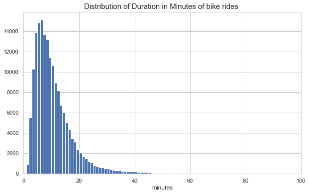

```python
b_size = 1
bins = np.arange(0, bikes_clean['duration_minutes'].max()+b_size, b_size)

fig(10,6)
plt.hist(data=bikes_clean, x='duration_minutes', bins=bins)
plt.xlim(0,100) # zooming in on values between 0-100 since tat is where most lie
plt.xlabel('minutes')
plt.title('Distribution of Duration in Minutes of bike rides ', size=15);
```

```python
# subsetting for bike rides that lasted for less than a 100 minutes
sub_min = bikes_clean[bikes_clean['duration_minutes'] < 100]
np.log10(sub_min['duration_minutes'].describe())
```

```
count    5.241168
mean     1.023807
std      0.927569
min      0.000000
25%      0.698970
50%      0.903090
75%      1.113943
max      1.995635
Name: duration_minutes, dtype: float64
```

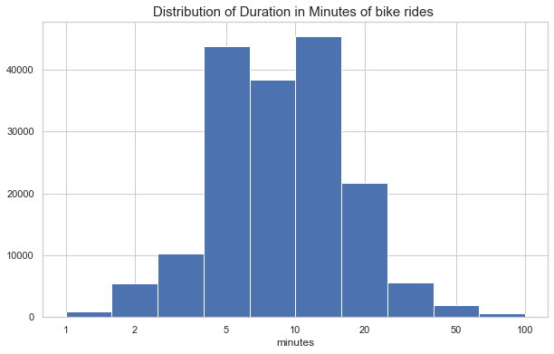

```python
# putting it on a log scale because of the long tailed distribution
b_size = 0.2
bins = 10 **np.arange(0, 2+b_size, b_size)

fig(10,6)
plt.hist(data=sub_min, x='duration_minutes', bins=bins)
plt.xscale('log')
ticks = [1,2,5,10,20,50,100]
labels = [1,2,5,10,20,50,100]
plt.xticks(ticks, labels)
plt.xlabel('minutes')
plt.title('Distribution of Duration in Minutes of bike rides ', size=15);
```

- The duration_minutes column has a largely long tailed distribution with a majority of the bike rides lasting between 1 and 40 minutes. In a logscale distribution,it can be seen that the distribution is slightly bimodal with a the first peak between 3-5 minutes and the other between 10 and 15 minutes.
- Next we look at how bike rides are distributed across time of the day.

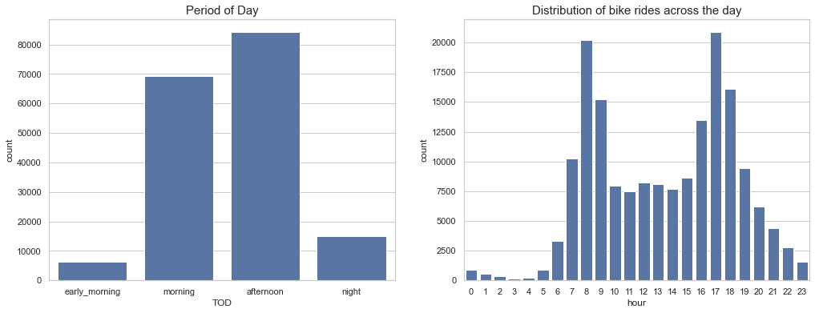

```python
fig(17,6)

plt.subplot(1,2,1)
countplot('TOD', 'Period of Day')

plt.subplot(1,2,2)
countplot('hour', 'Distribution of bike rides across the day');
```

- Most bike rides occur in the afternoon(between 12pm and 7pm), followed by morning bike rides(between 6am and 12 pm)
- The distribution the hours column is roughtly bimodal with 2 peaks. The fist peak is at 8am and the other at 5pm
- It will be interesting to have a look at how the duration of the bike rides is distributed across the day.

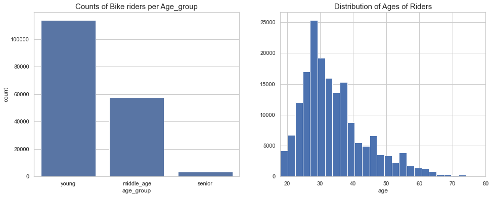

```python
fig(16,6)

plt.subplot(1,2,1)
countplot('age_group', 'Counts of Bike riders per Age_group')

plt.subplot(1,2,2)
bins = 45
plt.hist(data=bikes_clean, x='age', bins=bins)
# zooming in on ages between 18 and 80
plt.xlim(18,80)
plt.xlabel('age')
plt.title('Distribution of Ages of Riders', size=15);
```

```python
bikes_clean['age_group'].value_counts()
```

```
young         114024
middle_age     57399
senior          3529
Name: age_group, dtype: int64
```

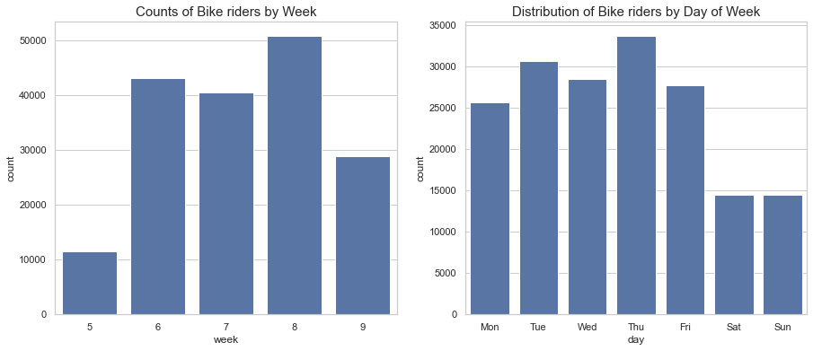

```python
# visualizing month column
fig(15,6)

plt.subplot(1,2,1)
countplot('week','Counts of Bike riders by Week')

plt.subplot(1,2,2)
countplot('day','Distribution of Bike riders by Day of Week');
```

- The number of bike rides were very low at the start of the month but there was a spike the following week before a dip then the highest peak of the month on the final fourth week. The last week saw a dip in the number of bike riders.
- The highest number of bike rides during the week happen on thursday.
- The weekends have the lowest number of bike riders for the whole week.
- The distribution of ages of bike riders and days of the week they ride could be insightful to have a look at.

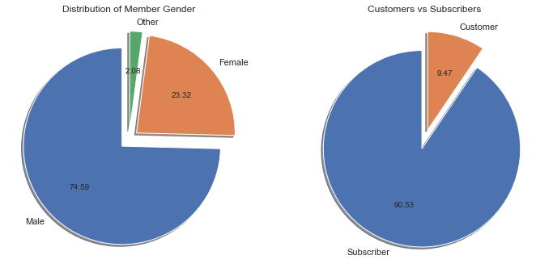

```python
fig(12,6)

plt.subplot(1,2,1)
bikes_clean['member_gender'].value_counts().plot(kind='pie', autopct='%.2f', startangle=90, ylabel='',
                                                title='Distribution of Member Gender', explode=[0.1,0.1,0.1], shadow=True);

plt.subplot(1,2,2)
bikes_clean['user_type'].value_counts().plot(kind='pie', autopct='%.2f', startangle=90, ylabel='',
                                            title='Customers vs Subscribers', explode=[0.1,0.1], shadow=True);
```

- 74.5% of bike riders are male followed by 23.32% female bike riders.
- 90.53% of people who ride the bikes are subscribers of the service as opposed to 9.47% who are customers only.
- An interesting aspect to look at will be how the user_type is distributed across the day of the week.
- Also, the distribution of member gender and user type as well as member gender and age could be worth a look.

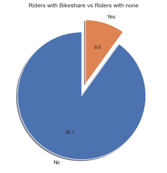

```python
bikes_clean['bike_share_for_all_trip'].value_counts().plot(kind='pie', autopct='%.1f', startangle=90,
                                                           ylabel='', title='Riders with Bikeshare vs Riders with none',
                                                           figsize=(6,6), shadow=True, explode=[0.1,0.1]);
```

- 90.1% of all bike riders have not enrolled for the bike-share for all program

### Of the features you investigated, were there any unusual distributions? Did you perform any operations on the data to tidy, adjust, or change the form of the data? If so, why did you do this?

- Because of the few large outliers in the duration_minute column which aused a long tailed distribution, had touse a log scale distribution and zoom in on values <100 minutes. It was also very interesting to find that a mojority of the bike riders only ride the bike for less than 40 minutes.
- In the hour column, ther 2 peaks at 8am and 5pm. Also, there was a significant amount of bike riders one hour befor and one hour after the 2 peaks.
- Another interesting distribution was that of the day column, where the weekdays recorded the highest number of riders while the number of riders on the weekend was considerable low in comparison.

## Bivariate Exploration

```python
# countplot fxn for bivariate plotting
def bicountplot(col, hue, title):
    sns.countplot(data=bikes_clean, x=col, hue=hue, palette='Blues')
    plt.title(title, size=15)
```

```python
num_vars = ['age', 'duration_minutes', 'hour']
cat_vars = ['age_group', 'TOD', 'day', 'week','member_gender', 'user_type']
```

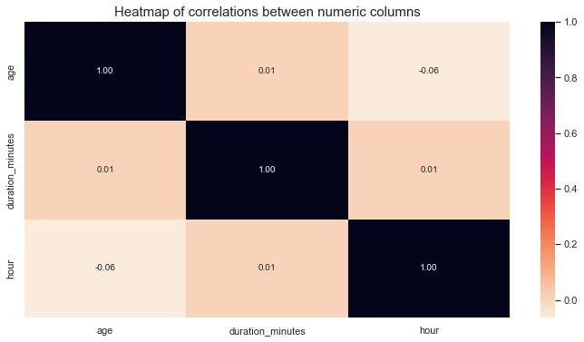

```python
# lets have a look at the pairwise relationships between the numeric vars of interest
fig(12,6)
sns.heatmap(bikes_clean[num_vars].corr(), cmap='rocket_r', annot=True, fmt='.2f')
plt.title('Heatmap of correlations between numeric columns', size=15);
```

- Interestigly there seems to be no correlation between hour, age, and duration in minutes.

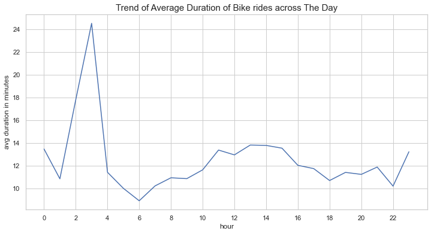

```python
# grouping hour and getting the mean of the duration in minutes
df_hr = bikes_clean.groupby('hour')['duration_minutes'].mean().reset_index()

# trend of duration throughout the day
fig(12,6)
sns.lineplot(data=df_hr, x='hour', y='duration_minutes')
plt.xticks([0,2,4,6,8,10,12,14,16,18,20,22])
plt.ylabel('avg duration in minutes')
plt.title('Trend of Average Duration of Bike rides across The Day', size=15);
```

- The duration of bike rides during the peak hour of 7-9am and 4-6pm are less than 12 minutes on average. Which could indicate the most people riding a bike to work, do now work at places that are far away.
- There's peak in average duration_minutes between 1am and 4am.

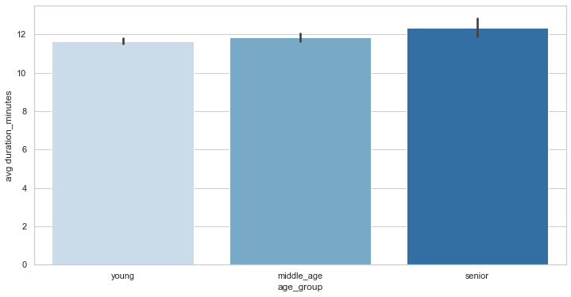

```python
# visualizing age_group and duration
fig(12,6)
sns.barplot(data=bikes_clean, x='age_group', y='duration_minutes', palette='Blues')
plt.ylabel('avg duration_minutes');
```

- Interestingly, its seems that the average duration rides vary very slighlty by age-roup, with young riders(18-35) having a low average while seniors(> 60 years) have a higher average
- This makes sense since younger riders are generally more energetic, hence are able to ride their bikes faster.

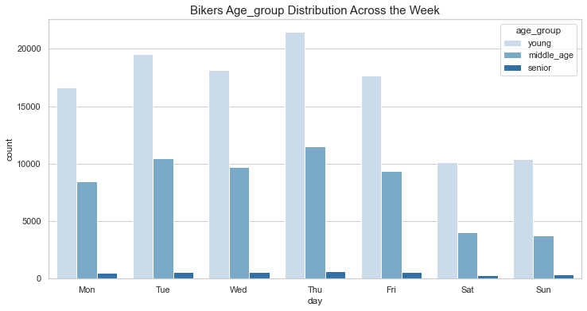

```python
fig(12,6)
bicountplot('day', 'age_group', 'Bikers Age_group Distribution Across the Week');
```

- From the above plot, it seems that young people(18-35) compose the largest group of bike riders throught the week.

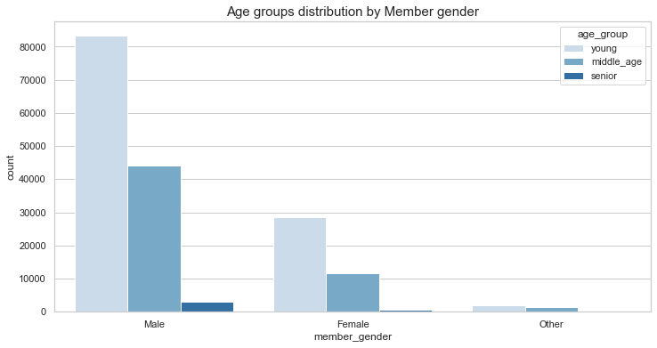

```python
#  age_group versus member_gender
fig(12,6)
sns.countplot(data=bikes_clean, x='member_gender', hue='age_group', palette='Blues',
              order=['Male', 'Female', 'Other'])
plt.title('Age groups distribution by Member gender', size=15);
```

- In both male and female groupings, it is the young persons the are highest in number.
- Interestingly though, it sees that the number of middle_age men riding bikes is higher than number of young female riders.

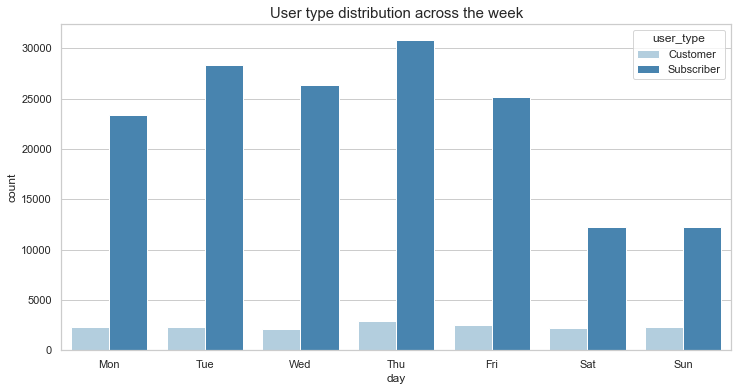

```python
# day of the week versus user_type
fig(12,6)
bicountplot('day','user_type', 'User type distribution across the week');
```

- The number of bike riders who are subscribers is consistently higher than that of customers throughout the week.
- overall the number of customers remans very low

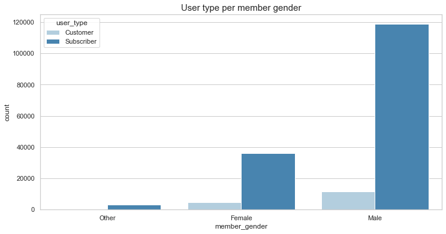

```python
# user type vs member gender
plt.figure(figsize=(12,6))
sns.countplot(data=bikes_clean, x='member_gender', hue='user_type', palette='Blues', order=['Other','Female','Male'])
plt.title('User type per member gender', size=15);
```

- When it comes to subscribers it is male bike riders that are high in number followed by female bike riders and those who did not indicate their gender.

### Talk about some of the relationships you observed in this part of the investigation. How did the feature(s) of interest vary with other features in the dataset?

- From the heatmap, it was evdent that there is no relationship between the age, hour and duration minutes column.
- The duration of bike rides during the peak hour of 7-9am and 4-6pm are less than 12 minutes on average. Which could indicate the most people riding a bike to work, do not work at places that are far away and are the same people who ride back in the evening. This could also mean that the duration of the bike rides is correlated to the time in which the bike ride is taking place.
- It was observed that on average, young the bike riders ride bikes for shorter durations while the seniors have a higher average duration.
- As expected, it is the group of bike riders in the young category that ride bike the most throught the week, followd by middle_age riders.
- Also, it is evident that highest group of bike riders are young male bike riders, followed by middle_age males and finaly young female bike riders.
- For the user_type and day column, it is seen that day of the week has no corelation with user_type since, for all days of the week, the highest number of bike riders were subscribers.
- Most of the subscribers are male, followed by female subscribers. Also, all cutomers did indicate their gender, only a smal number of subscribers did not.

## Multivariate Exploration

- First we look at how age_group and average duration of bike rides vary across the day

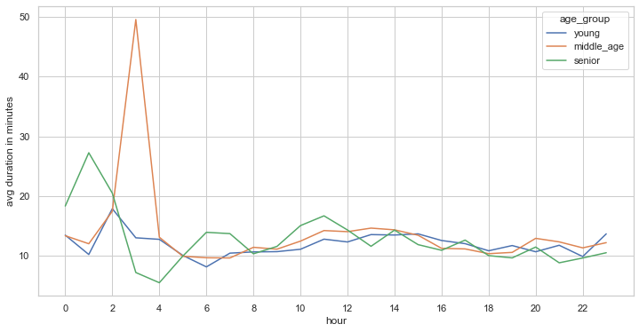

```python
# grouping hour and getting the mean of the duration in minutes
df_hr = bikes_clean.groupby(['hour','age_group'])['duration_minutes'].mean().reset_index()

# trend of duration throughout the day
plt.figure(figsize=(12,6))
sns.lineplot(data=df_hr, x='hour', y='duration_minutes', hue='age_group')
plt.xticks([0,2,4,6,8,10,12,14,16,18,20,22])
plt.ylabel('avg duration in minutes');
```

- The different age groups have flactuating average duration in minutes across the day. Between midnight and 3 am is when the different age_groups of bike riders have highly flactuating average durations. But for most of the day, the trends of their average duration does not vary a lot as it did at the start of the day.

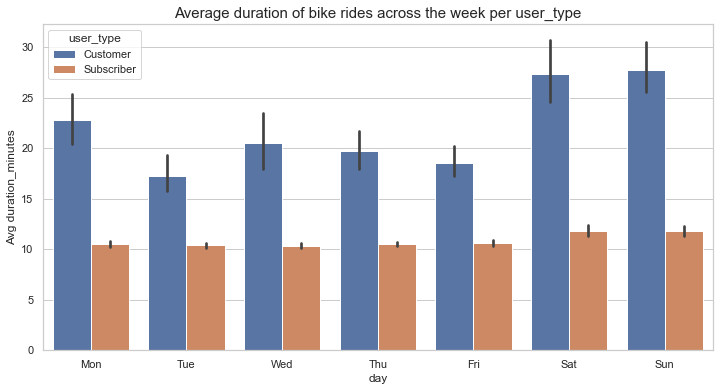

```python
fig(12,6)
sns.barplot(data=bikes_clean, x='day', y='duration_minutes', hue='user_type')
plt.ylabel('Avg duration_minutes')
plt.title('Average duration of bike rides across the week per user_type', size=15);
```

### Talk about some of the relationships you observed in this part of the investigation. Were there features that strengthened each other in terms of looking at your feature(s) of interest?

- It was clear that over the weekend the average duration of bike rides was highest for the whole week for both the cutsomers and subscribers.
- except for early morning, the duration of the ridesthrought the day does not fluctuate as much when you categorize the riders by age group. This supports the early conclusion that there is no meaningful correlation between age and hour as seen in the heatmap

### Were there any interesting or surprising interactions between features?

- No, there were no surprising interactions between the features.

```python
bikes_clean.to_csv('bikes_clean.csv')
```